# Quels est l’impact des fêtes de fin d’année sur Qualité de l’air?

Roumagnac Hugo, Ait Mahamed Salim

# 1 Partie informatique:

## 1.1 Diagramme d’activités

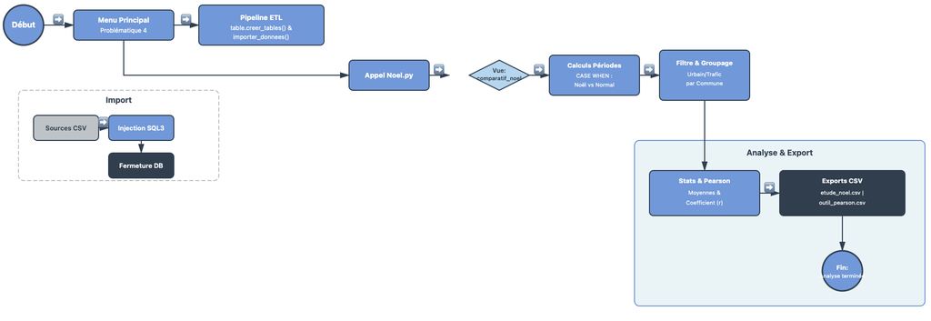

# 2 Requêtes SQL pour répondre au problème statistique

## 2.1 Justification du choix des Vues SQL

L’utilisation de vues plutôt que de tables physiques pour préparer nos analyses statistiques répond à un impératif de flexibilité et de fiabilité. Contrairement à une table, la vue ne duplique pas les données ; elle agit comme une fenêtre dynamique sur les tables sources, garantissant que les exports CSV sont toujours basés sur les données les plus récentes sans risque de désynchronisation. Ce choix permet d’isoler des calculs complexes (moyennes, agrégations) dans une structure virtuelle stable, simplifiant ainsi le passage de la base de données brute à l’outil statistique tout en optimisant l’espace de stockage. En résumé, la vue transforme la donnée technique en information métier exploitable de manière transparente et sécurisée.

- **CREATE VIEW AS** : Correspond à une instruction de définition ; elle permet d’enregistrer notre requête sous un nom simple. L’avantage est qu’à chaque fois qu’on l’appelle, les données sont recalculées sans occuper d’espace de stockage permanent.
- **SELECT**: Correspond à l’instruction d’extraction des colonnes que l’on souhaite sélectionner pour l’analyse.
- **CASE WHEN**: Correspond à une instruction conditionnelle ; elle permet ici de créer un “pivot” pour ventiler les données de pollution dans des colonnes spécifiques selon le mois ou la saison.
- **WHERE**: Correspond à une instruction de filtrage, qui restreint l’analyse aux données respectant des critères de temps, de polluant et de contexte géographique.
- **GROUP BY**: Correspond à une instruction de regroupement ; elle rassemble les relevés en fonction de leur typologie et de leur influence pour permettre les calculs statistiques.
- **AVG**: Correspond à une fonction d’agrégation ; elle permet le calcul de la moyenne arithmétique des concentrations de polluants.

## 2.2 Affichage d’une requête ayant pour objectif d’être extraite en fichier CSV

Pour analyser l’effet des fêtes sur la pollution, nous avons créé une vue SQL nommée `comparatif_noel` à partir de la table `QUALITE_AIR`. L’objectif est de mettre en opposition les niveaux de pollution entre la routine de décembre et la période spécifique des vacances de fin d’année.

Dans notre requête, nous utilisons un filtre `WHERE` pour nous concentrer uniquement sur le `NOX`. Nous avons choisi de cibler exclusivement les stations `Urbaines` sous influence `Trafic`.

Pour obtenir des chiffres comparables, nous utilisons la fonction `AVG` avec des conditions `CASE WHEN`. Cela nous permet de calculer en une seule fois la moyenne de pollution pour la période `normale` et celle pour la période de `Noel`. Nous utilisons ensuite un `GROUP BY` pour organiser ces résultats par ville.

Enfin, nous avons enregistré cette logique avec l’instruction `CREATE VIEW`. Cela transforme notre requête en une table virtuelle, ce qui est beaucoup plus simple pour automatiser nos calculs et exporter les résultats en `CSV`.

```
    cur.execute("""
        CREATE VIEW comparatif_noel AS
        SELECT
            nom_com AS Commune,
            AVG(CASE WHEN (annee = 2022 AND mois = 12 AND jour >= 20)
                       OR (annee = 2023 AND mois = 1 AND jour <= 5)
                THEN valeur_poll END) AS Moyenne_Noel,
            AVG(CASE WHEN (annee = 2022 AND mois = 12 AND jour BETWEEN 5 AND 19)
                THEN valeur_poll END) AS Moyenne_Normal
        FROM Qualite_Air
        WHERE nom_poll = 'NOX' AND typologie = 'Urbaine' AND influence = 'Trafic'
        GROUP BY nom_com
        HAVING Moyenne_Noel IS NOT NULL AND Moyenne_Normal IS NOT NULL;
    """)
```

# 3 Partie Statistique

## 3.1 Affinage de la problématique

Afin d’isoler l’impact des comportements saisonniers sur l’environnement, notre démarche s’est structurée autour d’une vue SQL spécifique. Cet outil nous a permis de segmenter temporellement les mesures de la table `Qualite_Air` pour mettre en opposition deux phases distinctes, la periode de fêtes de fin d’année et les deux premiérs semaine qui la précèdes.

Cette segmentation rigoureuse garantit que les variations observées et le calcul ultérieur du `coefficient de Pearson` reflètent de véritables changements d’habitudes citadines, plutôt que des fluctuations climatiques globales ou des émissions industrielles constantes.

## 3.2 Construire les tables contenant les informations nécessaires au traitement statistique

- La modalité **NOX** de la variable `nom_poll`,
- La modalité **Urbaine** de la variable `typologie`,
- La modalité **Trafic** de la variable `influence`,
- La modalité **2022** e la variable `annee`.
- La modalité **2023** e la variable `annee`.

## 3.3 Description des échantillons de données extraits

```r
noel <- read.csv(Ville,Pollution_Normal,Pollution_Noel,Ecart_Normal,Ecart_Noel)
```

```r
summary(noel)
```

```
##                           Ville   Pollution_Normal   Pollution_Noel
##  BEZIERS                     :1   Min.   :  0.9648   Min.   : 49.0
##  Coefficient de Corrélation r:1   1st Qu.: 94.1300   1st Qu.:110.9
##  MONTPELLIER                 :1   Median :143.4600   Median :132.1
##  PERPIGNAN                   :1   Mean   :117.6990   Mean   :125.0
##  TOULOUSE                    :1   3rd Qu.:166.9400   3rd Qu.:146.3
##                                   Max.   :183.0000   Max.   :186.8
##                                                      NA's   :1
##   Ecart_Normal        Ecart_Noel
##  Min.   :-52.7500   Min.   :-76.00
##  1st Qu.:-15.7525   1st Qu.:-14.13
##  Median :  8.3200   Median :  7.12
##  Mean   :  0.0025   Mean   :  0.00
##  3rd Qu.: 24.0750   3rd Qu.: 21.25
##  Max.   : 36.1200   Max.   : 61.76
##  NA's   :1          NA's   :1
```

## 3.4 Résumer des vues permetant l’analyse statistique

Le fichier `outil_statistique_pearson.csv` regroupe les métriques nécessaires à la réalisation de notre double étude. D’une part, une analyse univariée qui caractérise les concentrations de `NOX` durant les fêtes via le calcul de la `moyenne` globale. D’autre part, une analyse bivariée visant à quantifier la relation entre la pollution de la période “normale” et celle de la période de “Noël” grâce au coefficient de `corrélation de Pearson`.

```r
summary(noel)
```

```
##                           Ville   Pollution_Normal   Pollution_Noel
##  BEZIERS                     :1   Min.   :  0.9648   Min.   : 49.0
##  Coefficient de Corrélation r:1   1st Qu.: 94.1300   1st Qu.:110.9
##  MONTPELLIER                 :1   Median :143.4600   Median :132.1
##  PERPIGNAN                   :1   Mean   :117.6990   Mean   :125.0
##  TOULOUSE                    :1   3rd Qu.:166.9400   3rd Qu.:146.3
##                                   Max.   :183.0000   Max.   :186.8
##                                                      NA's   :1
##   Ecart_Normal        Ecart_Noel
##  Min.   :-52.7500   Min.   :-76.00
##  1st Qu.:-15.7525   1st Qu.:-14.13
##  Median :  8.3200   Median :  7.12
##  Mean   :  0.0025   Mean   :  0.00
##  3rd Qu.: 24.0750   3rd Qu.: 21.25
##  Max.   : 36.1200   Max.   : 61.76
##  NA's   :1          NA's   :1
```

L’analyse univariée a pour objectif d’étudier la distribution des taux de NOX (Oxydes d’Azote) spécifiquement pendant la trêve des confiseurs. En nous concentrant sur les stations de trafic urbain pour la période charnière entre 2022 et 2023, nous cherchons à établir si les comportements liés aux vacances et aux festivités modifient l’empreinte polluante habituelle des villes d’Occitanie.

## 3.5 Choix et justification des indicateurs et outils de visualisation

Pour transformer nos données brutes en informations exploitables, nous avons sélectionné des indicateurs statistiques précis et des modes de représentation graphique adaptés à notre problématique.

## 3.6 Justification des indicateurs statistiques

- **La Moyenne :** La moyenne nous sert à résumer la situation globale de chaque période (normale vs Noël) en un seul chiffre. Elle est indispensable pour répondre à notre question de base : “Est-ce qu’on pollue plus ou moins pendant les vacances ?”. En comparant la moyenne de la période normale avec celle de la période des fêtes, nous pouvons voir immédiatement s’il y a une hausse ou une baisse générale des émissions de `NOX` à l’échelle de la région.
- **La corrélation de Pearson (r) :** Le coefficient de Pearson nous permet d’aller plus loin que la simple moyenne. Son rôle est de mesurer la force du lien entre les deux périodes. Si `r` est proche de 1, cela signifie que les habitudes de pollution restent les mêmes, les villes les plus polluées en temps normal le restent exactement de la même façon pendant Noël. Si `r` diminue, cela montre que les vacances ont totalement bouleversé la hiérarchie habituelle.

En résumé, la moyenne nous donne l’évolution de la quantité de pollution, tandis que la corrélation nous indique si la structure de cette pollution a changé à cause du comportement des habitants pendant les festivités.

# 4 Analyse univariée des variables

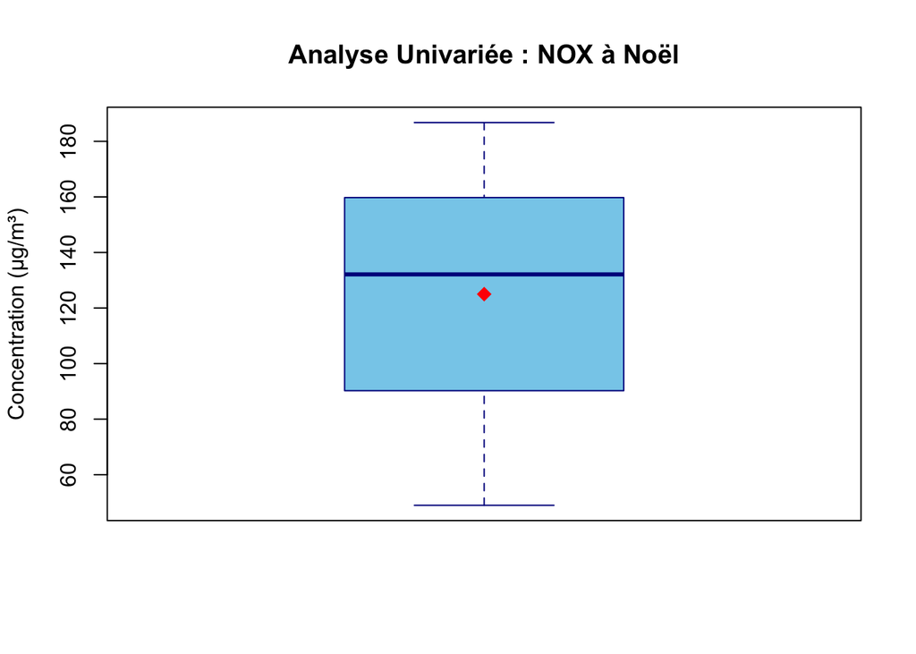

Distribution de la pollution au NOX pendant la période de Noël

```r
data <- read.csv("outil_statistique_pearson.csv")


data_clean <- data[data$Ville != "" & data$Ville != "Coefficient de Corrélation r", ]


data_clean$Pollution_Noel <- as.numeric(as.character(data_clean$Pollution_Noel))


boxplot(data_clean$Pollution_Noel,
        main = "Analyse Univariée : NOX à Noël",
        ylab = "Concentration (µg/m³)",
        col = "skyblue",
        border = "darkblue",
        notch = FALSE)


points(mean(data_clean$Pollution_Noel, na.rm = TRUE), col = "red", pch = 18, cex = 1.5)
```

L’analyse de la boîte interquartile permet d’identifier la structure de la pollution pour `50 %` des communes centrales de l’échantillon. Une boîte compacte indique une homogénéité des niveaux de `NOX` sur le territoire pendant les fêtes, tandis qu’un étalement important révèle des situations locales très disparates selon les zones urbaines.

La position verticale de la boîte sur l’échelle des μg/m 3 sert d’indicateur de santé atmosphérique saisonnière. Une boîte située en bas de l’échelle suggère que, malgré l’activité liée aux fêtes, la qualité de l’air reste respirable pour la majorité des communes d’Occitanie.

En conclusion cette étude univariée dresse l’état des lieux de la pollution atmosphérique à Noël. Elle permet de valider la cohérence de l’échantillon et de quantifier la variabilité des mesures avant toute comparaison avec les périodes normales. Ce diagnostic confirme que la nature de la donnée à Noël est stable, bien que ponctuée de disparités territoriales marquées par l’influence du trafic.

# 5 Analyse bivariée des variables et conclusion

## 5.1 Nuage de points

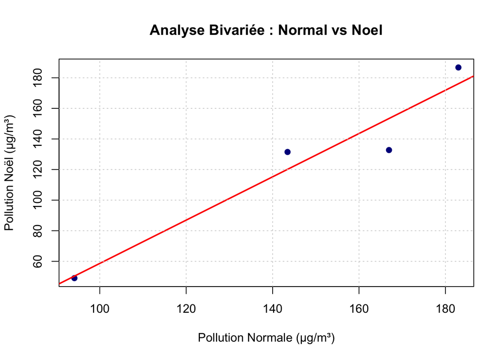

Corrélation des niveaux de NOX entre la période normale et Noël

```r
data_clean$Pollution_Normal <- as.numeric(as.character(data_clean$Pollution_Normal))
data_clean$Pollution_Noel <- as.numeric(as.character(data_clean$Pollution_Noel))


plot(data_clean$Pollution_Normal, data_clean$Pollution_Noel,
     main = "Analyse Bivariée : Normal vs Noel",
     xlab = "Pollution Normale (µg/m³)",
     ylab = "Pollution Noël (µg/m³)",
     pch = 19, col = "darkblue")


abline(lm(Pollution_Noel ~ Pollution_Normal, data = data_clean), col = "red", lwd = 2)


grid()
```

- **La validation de la structure habituelle** : Le calcul du coefficient de Pearson r permet de mesurer la stabilité. Un coefficient proche de 1 démontre que la pollution reste structurelle, les pôles urbains à fort trafic habituel demeurent les points noirs de la région. Cela confirme que l’activité liée à Noël se calque sur le réseau routier existant sans déplacer les foyers de pollution majeurs.
- **La détection des mutations de mobilité** : L’observation des points s’écartant de la droite de régression peermet d’identifier les ruptures de comportement.
- **La synthèse de l’influence saisonnière** : Cette corrélation permet de définir si la période de fin d’année agit comme un simple prolongement de la pollution chronique ou comme un événement perturbateur.

# 6 Conclusion

# 7 Navigation

Retour à l’accueil

Problématique 1